# week4 project

```python
import pandas as pd
import numpy as np
import matplotlib.pyplot as plt
import seaborn as sns
from sklearn.preprocessing import LabelEncoder, StandardScaler, MinMaxScaler
from sklearn.linear_model import LinearRegression
import warnings
warnings.filterwarnings("ignore")
```

1. Import required libraries and read the dataset. (2 marks)

```python
app= pd.read_csv("Apps_data.csv")
```

```python
app.head()
```

|  | App | Category | Rating | Reviews | Size | Installs | Type | Price | Content Rating | Genres | Last Updated | Current Ver | Android Ver |
| --- | --- | --- | --- | --- | --- | --- | --- | --- | --- | --- | --- | --- | --- |
| 0 | Photo Editor & Candy Camera & Grid & ScrapBook | ART_AND_DESIGN | 4.1 | 159 | 19M | 10,000+ | Free | 0 | Everyone | Art & Design | January 7, 2018 | 1.0.0 | 4.0.3 and up |
| 1 | Coloring book moana | ART_AND_DESIGN | 3.9 | 967 | 14M | 500,000+ | Free | 0 | Everyone | Art & Design;Pretend Play | January 15, 2018 | 2.0.0 | 4.0.3 and up |
| 2 | U Launcher Lite – FREE Live Cool Themes, Hide ... | ART_AND_DESIGN | 4.7 | 87510 | 8.7M | 5,000,000+ | Free | 0 | Everyone | Art & Design | August 1, 2018 | 1.2.4 | 4.0.3 and up |
| 3 | Sketch - Draw & Paint | ART_AND_DESIGN | 4.5 | 215644 | 25M | 50,000,000+ | Free | 0 | Teen | Art & Design | June 8, 2018 | Varies with device | 4.2 and up |
| 4 | Pixel Draw - Number Art Coloring Book | ART_AND_DESIGN | 4.3 | 967 | 2.8M | 100,000+ | Free | 0 | Everyone | Art & Design;Creativity | June 20, 2018 | 1.1 | 4.4 and up |

```python
app.head()
```

|  | App | Category | Rating | Reviews | Size | Installs | Type | Price | Content Rating | Genres | Last Updated | Current Ver | Android Ver |
| --- | --- | --- | --- | --- | --- | --- | --- | --- | --- | --- | --- | --- | --- |
| 0 | Photo Editor & Candy Camera & Grid & ScrapBook | ART_AND_DESIGN | 4.1 | 159 | 19M | 10,000+ | Free | 0 | Everyone | Art & Design | January 7, 2018 | 1.0.0 | 4.0.3 and up |
| 1 | Coloring book moana | ART_AND_DESIGN | 3.9 | 967 | 14M | 500,000+ | Free | 0 | Everyone | Art & Design;Pretend Play | January 15, 2018 | 2.0.0 | 4.0.3 and up |
| 2 | U Launcher Lite – FREE Live Cool Themes, Hide ... | ART_AND_DESIGN | 4.7 | 87510 | 8.7M | 5,000,000+ | Free | 0 | Everyone | Art & Design | August 1, 2018 | 1.2.4 | 4.0.3 and up |
| 3 | Sketch - Draw & Paint | ART_AND_DESIGN | 4.5 | 215644 | 25M | 50,000,000+ | Free | 0 | Teen | Art & Design | June 8, 2018 | Varies with device | 4.2 and up |
| 4 | Pixel Draw - Number Art Coloring Book | ART_AND_DESIGN | 4.3 | 967 | 2.8M | 100,000+ | Free | 0 | Everyone | Art & Design;Creativity | June 20, 2018 | 1.1 | 4.4 and up |

1. Check the first few samples, shape, info of the data and try to familiarize yourself with different features. (2 marks)

```python
app.shape
```

```
(10841, 13)
```

```python
app.info()
```

```
<class 'pandas.core.frame.DataFrame'>
RangeIndex: 10841 entries, 0 to 10840
Data columns (total 13 columns):
 #   Column          Non-Null Count  Dtype
---  ------          --------------  -----
 0   App             10841 non-null  object
 1   Category        10841 non-null  object
 2   Rating          9367 non-null   float64
 3   Reviews         10841 non-null  object
 4   Size            10841 non-null  object
 5   Installs        10841 non-null  object
 6   Type            10840 non-null  object
 7   Price           10841 non-null  object
 8   Content Rating  10840 non-null  object
 9   Genres          10841 non-null  object
 10  Last Updated    10841 non-null  object
 11  Current Ver     10833 non-null  object
 12  Android Ver     10838 non-null  object
dtypes: float64(1), object(12)
memory usage: 1.1+ MB
```

```python
app.size
```

```
140933
```

```python
app.ndim
```

```
2
```

1. Check summary statistics of the dataset. List out the columns that need to be worked upon for model building. (2 marks)

```python
app.describe().T
```

|  | count | mean | std | min | 25% | 50% | 75% | max |
| --- | --- | --- | --- | --- | --- | --- | --- | --- |
| Rating | 9367.0 | 4.193338 | 0.537431 | 1.0 | 4.0 | 4.3 | 4.5 | 19.0 |

```python
app.describe(include="all")
```

|  | App | Category | Rating | Reviews | Size | Installs | Type | Price | Content Rating | Genres | Last Updated | Current Ver | Android Ver |
| --- | --- | --- | --- | --- | --- | --- | --- | --- | --- | --- | --- | --- | --- |
| count | 10841 | 10841 | 9367.000000 | 10841 | 10841 | 10841 | 10840 | 10841 | 10840 | 10841 | 10841 | 10833 | 10838 |
| unique | 9660 | 34 | NaN | 6002 | 462 | 22 | 3 | 93 | 6 | 120 | 1378 | 2832 | 33 |
| top | ROBLOX | FAMILY | NaN | 0 | Varies with device | 1,000,000+ | Free | 0 | Everyone | Tools | August 3, 2018 | Varies with device | 4.1 and up |
| freq | 9 | 1972 | NaN | 596 | 1695 | 1579 | 10039 | 10040 | 8714 | 842 | 326 | 1459 | 2451 |
| mean | NaN | NaN | 4.193338 | NaN | NaN | NaN | NaN | NaN | NaN | NaN | NaN | NaN | NaN |
| std | NaN | NaN | 0.537431 | NaN | NaN | NaN | NaN | NaN | NaN | NaN | NaN | NaN | NaN |
| min | NaN | NaN | 1.000000 | NaN | NaN | NaN | NaN | NaN | NaN | NaN | NaN | NaN | NaN |
| 25% | NaN | NaN | 4.000000 | NaN | NaN | NaN | NaN | NaN | NaN | NaN | NaN | NaN | NaN |
| 50% | NaN | NaN | 4.300000 | NaN | NaN | NaN | NaN | NaN | NaN | NaN | NaN | NaN | NaN |
| 75% | NaN | NaN | 4.500000 | NaN | NaN | NaN | NaN | NaN | NaN | NaN | NaN | NaN | NaN |
| max | NaN | NaN | 19.000000 | NaN | NaN | NaN | NaN | NaN | NaN | NaN | NaN | NaN | NaN |

1. Check if there are any duplicate records in the dataset? if any drop them. (2 marks)

```python
app.duplicated().sum()
```

```
483
```

```python
app.drop_duplicates(inplace=True)
```

```python
app.duplicated().sum()
```

```
0
```

1. Check the unique categories of the column 'Category', Is there any invalid category? If yes, drop them. (2 marks)

```python
app["Category"].unique()
```

```
array(['ART_AND_DESIGN', 'AUTO_AND_VEHICLES', 'BEAUTY',
       'BOOKS_AND_REFERENCE', 'BUSINESS', 'COMICS', 'COMMUNICATION',
       'DATING', 'EDUCATION', 'ENTERTAINMENT', 'EVENTS', 'FINANCE',
       'FOOD_AND_DRINK', 'HEALTH_AND_FITNESS', 'HOUSE_AND_HOME',
       'LIBRARIES_AND_DEMO', 'LIFESTYLE', 'GAME', 'FAMILY', 'MEDICAL',
       'SOCIAL', 'SHOPPING', 'PHOTOGRAPHY', 'SPORTS', 'TRAVEL_AND_LOCAL',
       'TOOLS', 'PERSONALIZATION', 'PRODUCTIVITY', 'PARENTING', 'WEATHER',
       'VIDEO_PLAYERS', 'NEWS_AND_MAGAZINES', 'MAPS_AND_NAVIGATION',
       '1.9'], dtype=object)
```

```python
app["Category"]= app["Category"].replace("1.9",np.nan)
```

```python
app.dropna(subset="Category", inplace =True)
```

```python
app["Category"].unique()
```

```
array(['ART_AND_DESIGN', 'AUTO_AND_VEHICLES', 'BEAUTY',
       'BOOKS_AND_REFERENCE', 'BUSINESS', 'COMICS', 'COMMUNICATION',
       'DATING', 'EDUCATION', 'ENTERTAINMENT', 'EVENTS', 'FINANCE',
       'FOOD_AND_DRINK', 'HEALTH_AND_FITNESS', 'HOUSE_AND_HOME',
       'LIBRARIES_AND_DEMO', 'LIFESTYLE', 'GAME', 'FAMILY', 'MEDICAL',
       'SOCIAL', 'SHOPPING', 'PHOTOGRAPHY', 'SPORTS', 'TRAVEL_AND_LOCAL',
       'TOOLS', 'PERSONALIZATION', 'PRODUCTIVITY', 'PARENTING', 'WEATHER',
       'VIDEO_PLAYERS', 'NEWS_AND_MAGAZINES', 'MAPS_AND_NAVIGATION'],
      dtype=object)
```

1. Check if there are missing values present in the column Rating, If any? drop them and and create a new column as 'Rating_category' by converting ratings to high and low categories(>3.5 is high rest low) (3 marks)

```python
app.isnull().sum()
```

```
App                  0
Category             0
Rating            1465
Reviews              0
Size                 0
Installs             0
Type                 1
Price                0
Content Rating       0
Genres               0
Last Updated         0
Current Ver          8
Android Ver          2
dtype: int64
```

```python
app["Rating"].isnull().sum()
```

```
1465
```

```python
app.dropna(subset="Rating", inplace =True)
```

```python
app.isnull().sum()
```

```
App               0
Category          0
Rating            0
Reviews           0
Size              0
Installs          0
Type              0
Price             0
Content Rating    0
Genres            0
Last Updated      0
Current Ver       4
Android Ver       2
dtype: int64
```

```python
app["Rating_Category"]=app["Rating"]
```

```python
app["Rating_Category"]=np.where(app["Rating_Category"]>3.5,"high","low")
```

1. Check the distribution of the newly created column 'Rating_category' and comment on the distribution. (2 marks)

```python
app["Rating_Category"].value_counts()
```

```
high    8012
low      880
Name: Rating_Category, dtype: int64
```

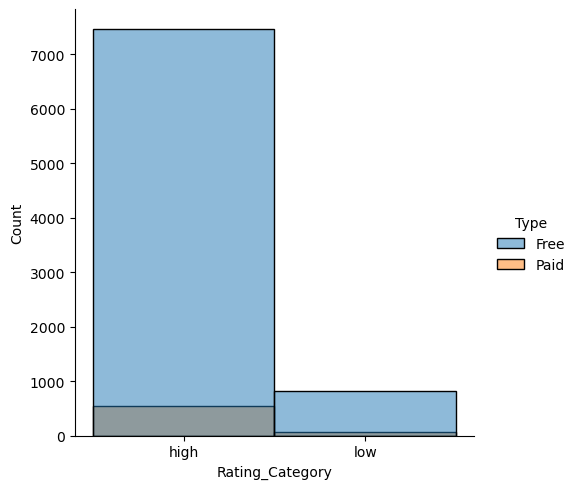

```python
sns.displot(x=app["Rating_Category"], hue=app["Type"])
plt.show()
```

Comment

most of the apps have high rating and are given for free apps

1. Convert the column "Reviews'' to numeric data type and check the presence of outliers in the column and handle the outliers using a transformation approach.(Hint: Use log transformation) (2 marks)

```python
app["Reviews"]=app["Reviews"].astype(int)
```

```python
app.dtypes
```

```
App                 object
Category            object
Rating             float64
Reviews              int32
Size                object
Installs            object
Type                object
Price               object
Content Rating      object
Genres              object
Last Updated        object
Current Ver         object
Android Ver         object
Rating_Category     object
dtype: object
```

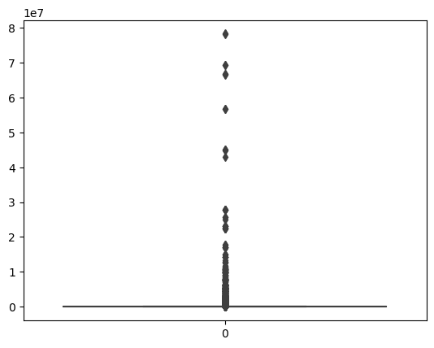

```python
sns.boxplot(app["Reviews"])
plt.show()
```

```python
app["Reviews"]= np.log(app["Reviews"])
```

```python
app["Reviews"]
```

```
0         5.068904
1         6.874198
2        11.379508
3        12.281384
4         6.874198
           ...
10834     1.945910
10836     3.637586
10837     1.386294
10839     4.736198
10840    12.894978
Name: Reviews, Length: 8892, dtype: float64
```

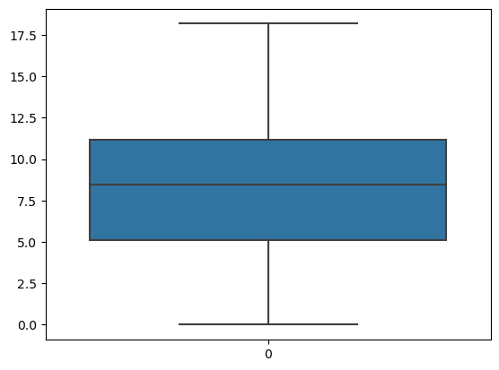

```python
sns.boxplot(app["Reviews"])
plt.show()
```

1. The column 'Size' contains alphanumeric values, treat the non numeric data and convert the column into suitable data type. (hint: Replace M with 1 million and K with 1 thousand, and drop the entries where size='Varies with device') (3 marks)

```python
app["Size"].unique()
```

```
array(['19M', '14M', '8.7M', '25M', '2.8M', '5.6M', '29M', '33M', '3.1M',
       '28M', '12M', '20M', '21M', '37M', '2.7M', '5.5M', '17M', '39M',
       '31M', '4.2M', '23M', '6.0M', '6.1M', '4.6M', '9.2M', '5.2M',
       '11M', '24M', 'Varies with device', '9.4M', '15M', '10M', '1.2M',
       '26M', '8.0M', '7.9M', '56M', '57M', '35M', '54M', '201k', '3.6M',
       '5.7M', '8.6M', '2.4M', '27M', '2.5M', '7.0M', '16M', '3.4M',
       '8.9M', '3.9M', '2.9M', '38M', '32M', '5.4M', '18M', '1.1M',
       '2.2M', '4.5M', '9.8M', '52M', '9.0M', '6.7M', '30M', '2.6M',
       '7.1M', '22M', '6.4M', '3.2M', '8.2M', '4.9M', '9.5M', '5.0M',
       '5.9M', '13M', '73M', '6.8M', '3.5M', '4.0M', '2.3M', '2.1M',
       '42M', '9.1M', '55M', '23k', '7.3M', '6.5M', '1.5M', '7.5M', '51M',
       '41M', '48M', '8.5M', '46M', '8.3M', '4.3M', '4.7M', '3.3M', '40M',
       '7.8M', '8.8M', '6.6M', '5.1M', '61M', '66M', '79k', '8.4M',
       '3.7M', '118k', '44M', '695k', '1.6M', '6.2M', '53M', '1.4M',
       '3.0M', '7.2M', '5.8M', '3.8M', '9.6M', '45M', '63M', '49M', '77M',
       '4.4M', '70M', '9.3M', '8.1M', '36M', '6.9M', '7.4M', '84M', '97M',
       '2.0M', '1.9M', '1.8M', '5.3M', '47M', '556k', '526k', '76M',
       '7.6M', '59M', '9.7M', '78M', '72M', '43M', '7.7M', '6.3M', '334k',
       '93M', '65M', '79M', '100M', '58M', '50M', '68M', '64M', '34M',
       '67M', '60M', '94M', '9.9M', '232k', '99M', '624k', '95M', '8.5k',
       '41k', '292k', '11k', '80M', '1.7M', '10.0M', '74M', '62M', '69M',
       '75M', '98M', '85M', '82M', '96M', '87M', '71M', '86M', '91M',
       '81M', '92M', '83M', '88M', '704k', '862k', '899k', '378k', '4.8M',
       '266k', '375k', '1.3M', '975k', '980k', '4.1M', '89M', '696k',
       '544k', '525k', '920k', '779k', '853k', '720k', '713k', '772k',
       '318k', '58k', '241k', '196k', '857k', '51k', '953k', '865k',
       '251k', '930k', '540k', '313k', '746k', '203k', '26k', '314k',
       '239k', '371k', '220k', '730k', '756k', '91k', '293k', '17k',
       '74k', '14k', '317k', '78k', '924k', '818k', '81k', '939k', '169k',
       '45k', '965k', '90M', '545k', '61k', '283k', '655k', '714k', '93k',
       '872k', '121k', '322k', '976k', '206k', '954k', '444k', '717k',
       '210k', '609k', '308k', '306k', '175k', '350k', '383k', '454k',
       '1.0M', '70k', '812k', '442k', '842k', '417k', '412k', '459k',
       '478k', '335k', '782k', '721k', '430k', '429k', '192k', '460k',
       '728k', '496k', '816k', '414k', '506k', '887k', '613k', '778k',
       '683k', '592k', '186k', '840k', '647k', '373k', '437k', '598k',
       '716k', '585k', '982k', '219k', '55k', '323k', '691k', '511k',
       '951k', '963k', '25k', '554k', '351k', '27k', '82k', '208k',
       '551k', '29k', '103k', '116k', '153k', '209k', '499k', '173k',
       '597k', '809k', '122k', '411k', '400k', '801k', '787k', '50k',
       '643k', '986k', '516k', '837k', '780k', '20k', '498k', '600k',
       '656k', '221k', '228k', '176k', '34k', '259k', '164k', '458k',
       '629k', '28k', '288k', '775k', '785k', '636k', '916k', '994k',
       '309k', '485k', '914k', '903k', '608k', '500k', '54k', '562k',
       '847k', '948k', '811k', '270k', '48k', '523k', '784k', '280k',
       '24k', '892k', '154k', '18k', '33k', '860k', '364k', '387k',
       '626k', '161k', '879k', '39k', '170k', '141k', '160k', '144k',
       '143k', '190k', '376k', '193k', '473k', '246k', '73k', '253k',
       '957k', '420k', '72k', '404k', '470k', '226k', '240k', '89k',
       '234k', '257k', '861k', '467k', '676k', '552k', '582k', '619k'],
      dtype=object)
```

```python
app["Size"].value_counts()
```

```
Varies with device    1468
14M                    154
13M                    152
12M                    151
11M                    150
                      ...
383k                     1
454k                     1
812k                     1
442k                     1
619k                     1
Name: Size, Length: 414, dtype: int64
```

```python
app['Size']=app['Size'].replace({'M':'e6','k':'e3'},regex = True)
```

```python
app['Size']=app['Size'].replace('Varies with device',np.nan)
```

```python
app["Size"].isna().sum()
```

```
1468
```

```python
app.dropna(subset="Size", inplace =True)
```

1. Check the column 'Installs', treat the unwanted characters and convert the column into a suitable data type.(2 marks

```python
app["Installs"].value_counts()
```

```
1,000,000+        1230
100,000+          1003
10,000+            949
10,000,000+        762
1,000+             675
5,000,000+         493
500,000+           471
50,000+            432
5,000+             414
100+               297
500+               195
100,000,000+       192
50,000,000+        144
10+                 67
50+                 56
500,000,000+        24
5+                   9
1,000,000,000+       8
1+                   3
Name: Installs, dtype: int64
```

```python
app["Installs"]=app["Installs"].str.replace("+","")
```

```python
app["Installs"]=app["Installs"].str.replace(",","")
```

```python
app["Installs"].astype(int)
```

```
0           10000
1          500000
2         5000000
3        50000000
4          100000
           ...
10833        1000
10834         500
10836        5000
10837         100
10840    10000000
Name: Installs, Length: 7424, dtype: int32
```

```python
app["Installs"]
```

```
0           10000
1          500000
2         5000000
3        50000000
4          100000
           ...
10833        1000
10834         500
10836        5000
10837         100
10840    10000000
Name: Installs, Length: 7424, dtype: object
```

1. Check the column 'Price' , remove the unwanted characters and convert the column into a suitable data type. (2 marks)

```python
app["Price"].value_counts()
```

```
0          6877
$0.99       104
$2.99        98
$4.99        61
$1.99        53
           ...
$6.49         1
$1.29         1
$299.99       1
$379.99       1
$1.20         1
Name: Price, Length: 68, dtype: int64
```

```python
app["Price"]=app["Price"].str.replace("$","")
```

```python
app["Price"].astype(float)
```

```
0        0.0
1        0.0
2        0.0
3        0.0
4        0.0
        ...
10833    0.0
10834    0.0
10836    0.0
10837    0.0
10840    0.0
Name: Price, Length: 7424, dtype: float64
```

1. Drop the columns which you think redundant for the analysis.(suggestion: drop column 'rating', since we created a new feature from it (i.e. rating_category) and the columns 'App', 'Rating' ,'Genres','Last Updated', 'Current Ver','Android Ver' columns since which are redundant for our analysis) (2 marks)

```python
app.drop(['App','Rating','Genres','Last Updated','Current Ver','Android Ver'],inplace=True,axis = 1)
```

```python
app.head()
```

|  | Category | Reviews | Size | Installs | Type | Price | Content Rating | Rating_Category |
| --- | --- | --- | --- | --- | --- | --- | --- | --- |
| 0 | ART_AND_DESIGN | 5.068904 | 19e6 | 10000 | Free | 0 | Everyone | high |
| 1 | ART_AND_DESIGN | 6.874198 | 14e6 | 500000 | Free | 0 | Everyone | high |
| 2 | ART_AND_DESIGN | 11.379508 | 8.7e6 | 5000000 | Free | 0 | Everyone | high |
| 3 | ART_AND_DESIGN | 12.281384 | 25e6 | 50000000 | Free | 0 | Teen | high |
| 4 | ART_AND_DESIGN | 6.874198 | 2.8e6 | 100000 | Free | 0 | Everyone | high |

1. Encode the categorical columns. (2 marks)

```python
le=LabelEncoder()
```

```python
columns = ['Category','Type','Content Rating','Rating_Category']
for col in columns:
    app[col]=le.fit_transform(app[col])
```

```python
app.head()
```

|  | Category | Reviews | Size | Installs | Type | Price | Content Rating | Rating_Category |
| --- | --- | --- | --- | --- | --- | --- | --- | --- |
| 0 | 0 | 5.068904 | 19e6 | 10000 | 0 | 0 | 1 | 0 |
| 1 | 0 | 6.874198 | 14e6 | 500000 | 0 | 0 | 1 | 0 |
| 2 | 0 | 11.379508 | 8.7e6 | 5000000 | 0 | 0 | 1 | 0 |
| 3 | 0 | 12.281384 | 25e6 | 50000000 | 0 | 0 | 4 | 0 |
| 4 | 0 | 6.874198 | 2.8e6 | 100000 | 0 | 0 | 1 | 0 |

1. Segregate the target and independent features (Hint: Use Rating_category as the target) (2 marks)

```python
X = app.drop('Rating_Category',axis=1)
y = app[['Rating_Category']]
```

```python
X.head()
```

|  | Category | Reviews | Size | Installs | Type | Price | Content Rating |
| --- | --- | --- | --- | --- | --- | --- | --- |
| 0 | 0 | 5.068904 | 19e6 | 10000 | 0 | 0 | 1 |
| 1 | 0 | 6.874198 | 14e6 | 500000 | 0 | 0 | 1 |
| 2 | 0 | 11.379508 | 8.7e6 | 5000000 | 0 | 0 | 1 |
| 3 | 0 | 12.281384 | 25e6 | 50000000 | 0 | 0 | 4 |
| 4 | 0 | 6.874198 | 2.8e6 | 100000 | 0 | 0 | 1 |

```python
y.head()
```

|  | Rating_Category |
| --- | --- |
| 0 | 0 |
| 1 | 0 |
| 2 | 0 |
| 3 | 0 |
| 4 | 0 |

1. Split the dataset into train and test. (2 marks)

```python
from sklearn.model_selection import train_test_split
```

```python
X_train, X_test, y_train, y_test = train_test_split(X, y, test_size =0.30, random_state = 1)
```

```python
X_train.head()
```

|  | Category | Reviews | Size | Installs | Type | Price | Content Rating |
| --- | --- | --- | --- | --- | --- | --- | --- |
| 8888 | 0 | 0.000000 | 2.9e6 | 100 | 0 | 0 | 1 |
| 1298 | 15 | 12.120852 | 57e6 | 5000000 | 0 | 0 | 1 |
| 6599 | 20 | 5.733341 | 5.9e6 | 10000 | 0 | 0 | 1 |
| 7328 | 30 | 5.361292 | 6.1e6 | 5000 | 1 | 3.99 | 1 |
| 5681 | 18 | 4.043051 | 5.8e6 | 10000 | 0 | 0 | 1 |

```python
y_train.head()
```

|  | Rating_Category |
| --- | --- |
| 8888 | 0 |
| 1298 | 0 |
| 6599 | 0 |
| 7328 | 0 |
| 5681 | 0 |

```python
X_test.head()
```

|  | Category | Reviews | Size | Installs | Type | Price | Content Rating |
| --- | --- | --- | --- | --- | --- | --- | --- |
| 5708 | 29 | 6.552508 | 7.3e6 | 100000 | 0 | 0 | 1 |
| 7215 | 11 | 5.894403 | 14e6 | 1000 | 1 | 2.99 | 2 |
| 1350 | 15 | 11.174217 | 49e6 | 1000000 | 0 | 0 | 1 |
| 5727 | 29 | 11.272496 | 6.3e6 | 1000000 | 0 | 0 | 1 |
| 5326 | 11 | 9.205529 | 3.7e6 | 100000 | 0 | 0 | 4 |

```python
y_test.head()
```

|  | Rating_Category |
| --- | --- |
| 5708 | 0 |
| 7215 | 0 |
| 1350 | 0 |
| 5727 | 0 |
| 5326 | 0 |

1. Standardize the data, so that the values are within a particular range. (2 marks)

```python
scaler=StandardScaler()
```

```python
app = scaler.fit_transform(app)
```

```python
app
```

```
array([[-2.03766618, -0.67995305, -0.15992777, ..., -0.06305842,
        -0.46322046, -0.35358018],
       [-2.03766618, -0.19653147, -0.37330014, ..., -0.06305842,
        -0.46322046, -0.35358018],
       [-2.03766618,  1.0099001 , -0.59947486, ..., -0.06305842,
        -0.46322046, -0.35358018],
       ...,
       [-0.68621673, -1.0632313 ,  1.29100439, ..., -0.06305842,
        -0.46322046, -0.35358018],
       [-0.68621673, -1.66608206, -0.81711468, ..., -0.06305842,
        -0.46322046, -0.35358018],
       [ 0.17379656,  1.41571255, -0.15992777, ..., -0.06305842,
        -0.46322046, -0.35358018]])
```

```python
app = pd.DataFrame(app)
app
```

|  | 0 | 1 | 2 | 3 | 4 | 5 | 6 | 7 |
| --- | --- | --- | --- | --- | --- | --- | --- | --- |
| 0 | -2.037666 | -0.679953 | -0.159928 | -0.168764 | -0.282029 | -0.063058 | -0.463220 | -0.35358 |
| 1 | -2.037666 | -0.196531 | -0.373300 | -0.158181 | -0.282029 | -0.063058 | -0.463220 | -0.35358 |
| 2 | -2.037666 | 1.009900 | -0.599475 | -0.060990 | -0.282029 | -0.063058 | -0.463220 | -0.35358 |
| 3 | -2.037666 | 1.251404 | 0.096119 | 0.910911 | -0.282029 | -0.063058 | 2.517665 | -0.35358 |
| 4 | -2.037666 | -0.196531 | -0.851254 | -0.166820 | -0.282029 | -0.063058 | -0.463220 | -0.35358 |
| ... | ... | ... | ... | ... | ... | ... | ... | ... |
| 7419 | -1.669089 | -1.023974 | -0.944327 | -0.168958 | -0.282029 | -0.063058 | -0.463220 | -0.35358 |
| 7420 | -0.686217 | -1.516228 | -0.859789 | -0.168969 | -0.282029 | -0.063058 | -0.463220 | -0.35358 |
| 7421 | -0.686217 | -1.063231 | 1.291004 | -0.168872 | -0.282029 | -0.063058 | -0.463220 | -0.35358 |
| 7422 | -0.686217 | -1.666082 | -0.817115 | -0.168977 | -0.282029 | -0.063058 | -0.463220 | -0.35358 |
| 7423 | 0.173797 | 1.415713 | -0.159928 | 0.046999 | -0.282029 | -0.063058 | -0.463220 | -0.35358 |

7424 rows × 8 columns

PART 2

1. Import required libraries and read the dataset. (2 marks)

```python
import pandas as pd
import numpy as np
import seaborn as sns
import matplotlib.pyplot as plt
%matplotlib inline
```

```python
hp = pd.read_csv("honeyproduction.csv")
```

1. Check the first few samples, shape, info of the data and try to familiarize yourself with different features. (2 marks)

```python
hp.head()
```

|  | state | numcol | yieldpercol | totalprod | stocks | priceperlb | prodvalue | year |
| --- | --- | --- | --- | --- | --- | --- | --- | --- |
| 0 | AL | 16000.0 | 71 | 1136000.0 | 159000.0 | 0.72 | 818000.0 | 1998 |
| 1 | AZ | 55000.0 | 60 | 3300000.0 | 1485000.0 | 0.64 | 2112000.0 | 1998 |
| 2 | AR | 53000.0 | 65 | 3445000.0 | 1688000.0 | 0.59 | 2033000.0 | 1998 |
| 3 | CA | 450000.0 | 83 | 37350000.0 | 12326000.0 | 0.62 | 23157000.0 | 1998 |
| 4 | CO | 27000.0 | 72 | 1944000.0 | 1594000.0 | 0.70 | 1361000.0 | 1998 |

```python
hp.tail()
```

|  | state | numcol | yieldpercol | totalprod | stocks | priceperlb | prodvalue | year |
| --- | --- | --- | --- | --- | --- | --- | --- | --- |
| 621 | VA | 4000.0 | 41 | 164000.0 | 23000.0 | 3.77 | 618000.0 | 2012 |
| 622 | WA | 62000.0 | 41 | 2542000.0 | 1017000.0 | 2.38 | 6050000.0 | 2012 |
| 623 | WV | 6000.0 | 48 | 288000.0 | 95000.0 | 2.91 | 838000.0 | 2012 |
| 624 | WI | 60000.0 | 69 | 4140000.0 | 1863000.0 | 2.05 | 8487000.0 | 2012 |
| 625 | WY | 50000.0 | 51 | 2550000.0 | 459000.0 | 1.87 | 4769000.0 | 2012 |

```python
hp.info()
```

```
<class 'pandas.core.frame.DataFrame'>
RangeIndex: 626 entries, 0 to 625
Data columns (total 8 columns):
 #   Column       Non-Null Count  Dtype
---  ------       --------------  -----
 0   state        626 non-null    object
 1   numcol       626 non-null    float64
 2   yieldpercol  626 non-null    int64
 3   totalprod    626 non-null    float64
 4   stocks       626 non-null    float64
 5   priceperlb   626 non-null    float64
 6   prodvalue    626 non-null    float64
 7   year         626 non-null    int64
dtypes: float64(5), int64(2), object(1)
memory usage: 39.3+ KB
```

```python
hp.shape
```

```
(626, 8)
```

```python
hp.size
```

```
5008
```

1. Display the percentage distribution of the data in each year using the pie chart. (2 marks)

```python
hp["year"].unique()
```

```
array([1998, 1999, 2000, 2001, 2002, 2003, 2004, 2005, 2006, 2007, 2008,
       2009, 2010, 2011, 2012], dtype=int64)
```

```
<function matplotlib.pyplot.show(close=None, block=None)>
```

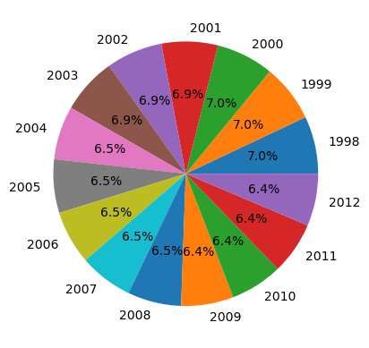

```python
years=['1998','1999','2000','2001','2002','2003','2004','2005','2006','2007','2008','2009','2010','2011','2012']
plt.pie(hp["year"].value_counts(), labels =years,autopct='%1.1f%%')
plt.show
```

1. Plot and Understand the distribution of the variable "price per lb" using displot, and write your findings. (2 marks)

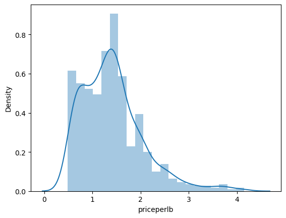

```python
sns.distplot(hp["priceperlb"])
plt.show()
```

Findings

we can clearly see that average price per pound based on expanded sales is hig in bwtween 1$ to 2$ and the plot is positively skewed

1. Plot and understand the relationship between the variables 'numcol' and 'prodval' through scatterplot, and write your findings. (2 marks)

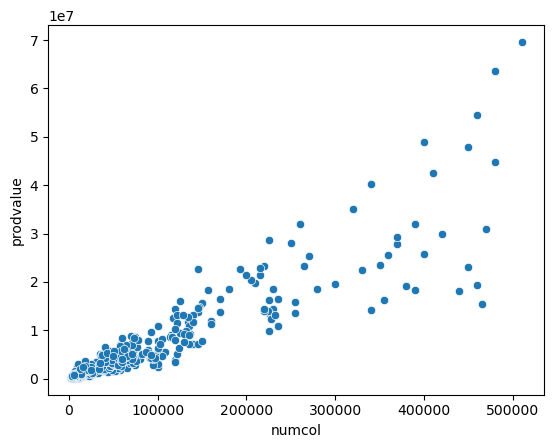

```python
sns.scatterplot(x= "numcol", y ="prodvalue", data = hp)
plt.show()
```

nomcol and prodvalue have positive corelation. There will be an increase in value of production for increase in number of honey producing colonies.

1. Plot and understand the relationship between categorical variable 'year' and a numerical variable 'prodvalue' through boxplot, and write your findings. (2 marks)

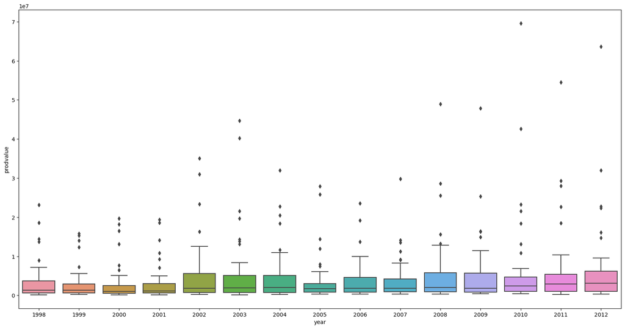

```python
plt.figure(figsize=(20,10))
sns.boxplot(x= hp["year"], y = hp["prodvalue"])
plt.show()
```

findings

the median value for each each is nearly the same and has a lot of outliers in each year. All the outliers are to the maximum line that is Q3+1.5*IQR

1. Visualize and understand the relationship between the multiple pairs of variables throughout different years using pairplot and add your inferences. (use columns 'numcol', 'yield percol', 'total prod', 'prodvalue','year') (2 marks)

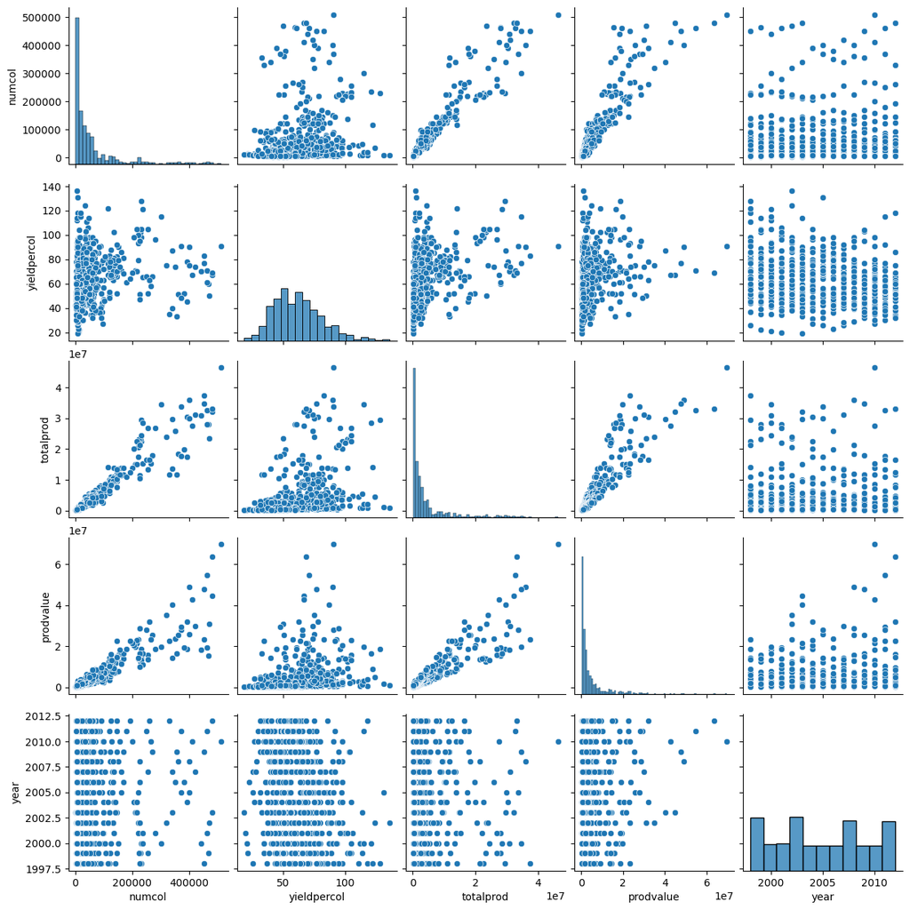

```python
sns.pairplot(hp[[ 'numcol', 'yieldpercol', 'totalprod', 'prodvalue','year']])
plt.show()
```

1. Display the correlation values using a plot and add your inferences. (use columns 'numcol', 'yield percol', 'total prod', 'stocks', 'price per lb', 'prodvalue') (2 marks)

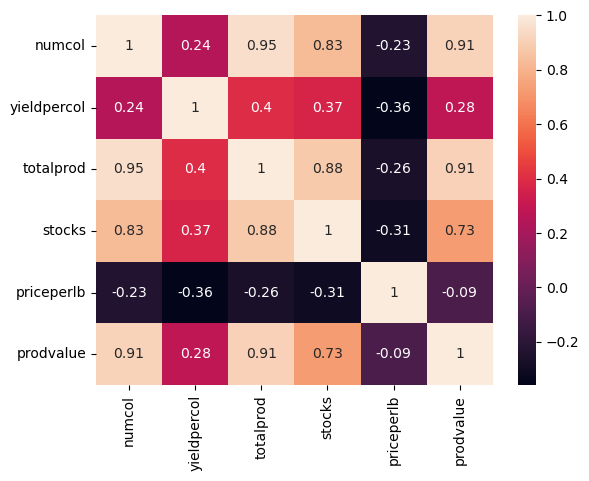

```python
sns.heatmap(hp[['numcol', 'yieldpercol', 'totalprod', 'stocks', 'priceperlb','prodvalue']].corr(),annot = True)
plt.show()
```

Inferences

priceperlb is negatively corelated to stocks, totalprod,yeildpercol, numcol which means priceperlb is inversely proportional to all other attributes.

numcol has strong positive corelation among totalprod, stocks, prodvalue

stocks has positive corelation with totalprod

prodvalue has high positive corelation of 0.91 with totalprod